# Visualising spatial data and creating maps in R

Week 3

### Outline:

In this session, you will be introduced to how to use R to manipulate spatial data (e.g. raster data and polygon data such as shapefiles), the importance of coordinate reference systems (CRSs) and how these data can be used to generate maps.

#### Learning outcomes

At the end of this workshop you will be able to use R to:

- Import and manipulate polygon and raster data;
- Change CRSs to ensure your maps accurately represent the spatial data they are showing;
- Create basic maps to show spatial patterns in census and environmental data.

#### Essential reading:

- A good starting point for understanding spatial data can be found in the paper associated with the **tmap** package created by Tennekes (2018): Tennekes, M. (2018). tmap: Thematic Maps in R. *Journal of Statistical Software*, 84(6), 1–39. https://doi.org/10.18637/jss.v084.i06 [click on the ‘paper’ box].
- A thorough outline of geographical data formats can be found in **Chapter 2** of Lovelace et al. (2024) *Geocomputation with R*. (2nd Ed): https://r.geocompx.org/spatial-class

### A brief introduction to spatial data

Dealing with spatial in R, or any Geographical Information System (GIS) for that matter, requires that you understand how spatial data are created and also represented or projected. We will start by introducing you to the raster/vector data models. Raster datasets are an important source of geographic data and frequently derived from aerial photography and satellite-based remote sensing products offering data on, for example, land surface temperatures, atmospheric pollutants, vegetation height, etc.

##### Polygon data and shapefiles

The vector data model represents the geographical data using polygons (e.g. boundaries of Birmingham’s LOAs, land cover classes), lines (e.g. Rail and road networks), points (e.g. occurrences of crimes, road traffic accidents). These have discrete, well-defined borders and can be combined (Figure 1). They are not neccessarily accurate however. The file types associated with shapefiles generally have a **’*.shp’** suffix but Other popular spatial vector file formats include GeoJSON (.geojson), GPX (.gpx), and KML (.kml). When using a gis they are accompanied by a run of other files: ‘.dbf’,‘.cpg’,‘.prj’,‘.qmd’,‘.shx’ that need to sit in the subdirectory.

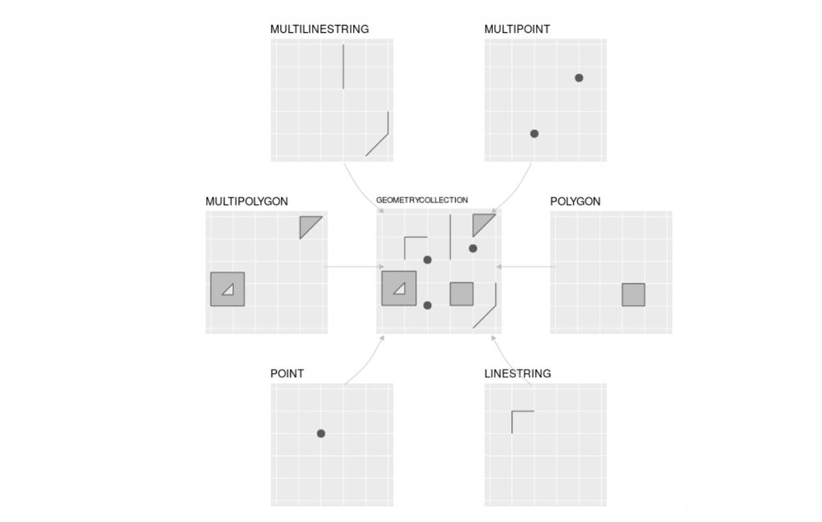

**Figure 1**: Different shapefiles formats available in the **sf** package (Source: Lovelace et al. 2024).

##### Raster data

The raster data model divides the surface up into cells (or grids) of constant size but at varying spatial scales (generally presented as metres, kilometers of decimal degrees). Raster datasets are an important source of geographic data and frequently derived from aerial photography and satellite-based remote sensing products offering ***continuous** data on, for example, land surface temperatures, atmospheric pollutants, vegetation height, but it can be **categorical** data such as land or soil cover classes (Figure 2). Typical files types include: **geotiff** and **asc**.

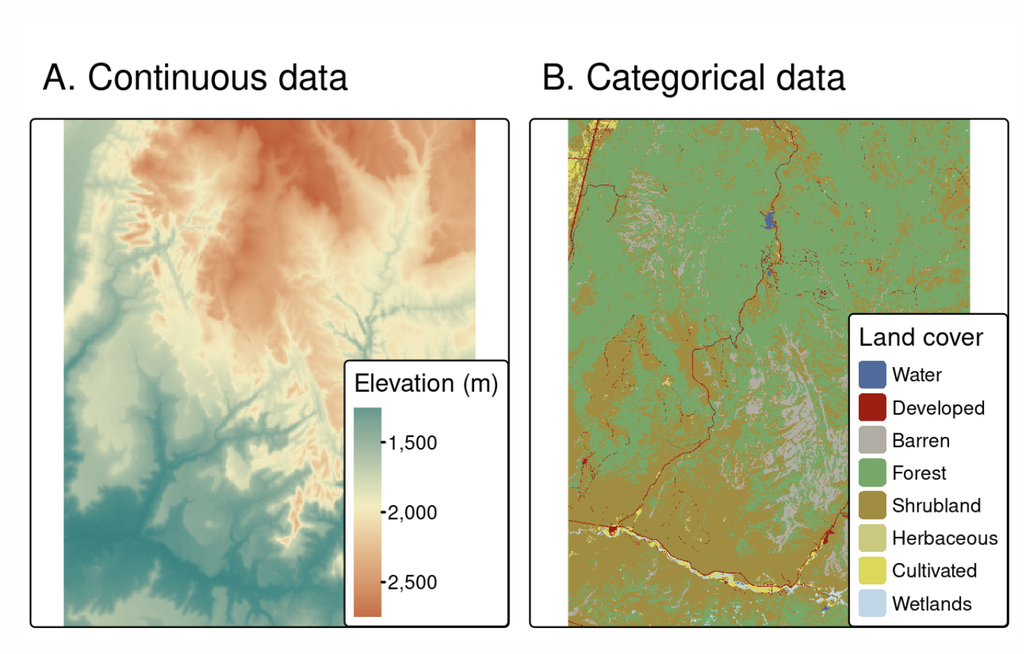

**Figure 2:** Examples of continuous (A) and categorical raster data (Source: Lovelace et al. 2024)

#### Coordinate reference systems

Coordinate reference systems (CRSs) provide information on how the geographical data will be projected when it is mapped. These are tricky to get your head around. Geographic CRSs identify any location on the Earth’s surface using two values — longitude and latitude. Longitude is location in the East-West direction in angular distance from the Prime Meridian plane (Figure 3). Latitude is angular distance North or South of the equatorial plane. Distances in geographic CRSs are therefore not measured in meters. These values are used to project the map when you display it. You can transforms between CRSs from an ellipsoid to a flat plane to deliver units that accurately measure in metres and thus can be appropriately calculate the area of a shapfile or raster feature. The UK Ordance Survey Grid for examples is organised in this way as is UMT grid. That is all you need to know about these for the time being but make sure you read section *2.4.1 **in Lovelace et al. (2024) *Geocomputation with R*. (2nd Ed),** before** next week’s workshop.

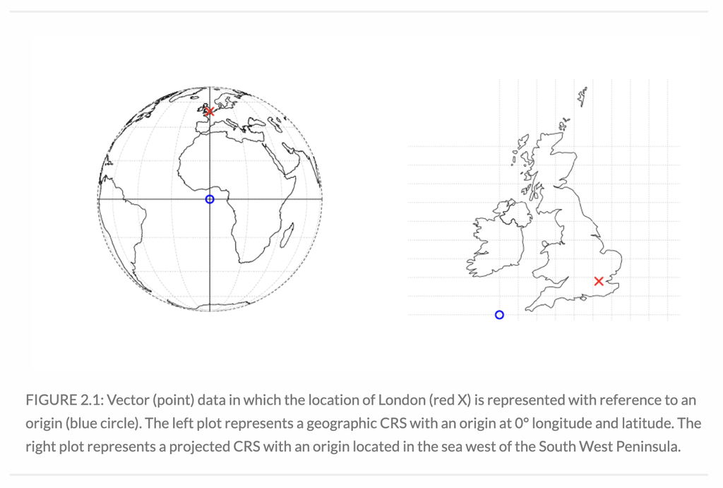

**Figure 3:** Examples of CRS repsentations of geographical data (Source: Lovelace et al. 2024)

#### Stellar examples of maps in R

If you want to see what’s possible with R’s mapping capabilities then I refer to **Milos makes maps** tutorials on YouTube:

https://www.youtube.com/@milos-makes-maps

Please have a watch of a few of them - it will help consolidate the functions and packages we are going to use as well as provide you with some useful coding tips!

### Today’s session

First up we need to install some new libraries and set our working directory.

#### Install libraries

The R functions for managing these datasets are relatively straightforward, having some similarities to ggplot2, but they are in a set of bespoke libraries as well as the tidyverse library we’ve been working with.

We need the following packages:

- **“sf”** - Read about it: https://r-spatial.github.io/sf/. Used to manage shapefiles, point data and so on.
- **“terra”** - Read about it: https://rspatial.org/pkg/1-introduction.html. Used to manage spatial raster data.
- **“spdep”** - https://cran.r-project.org/web/packages/spdep/index.html. Used for geospatial analyses such as nearest neighbour analyses. See Roger Bivand’s book on the module resource list.
- **“mapsf”** - https://riatelab.github.io/mapsf/articles/mapsf.html. The aim of mapsf is to obtain thematic maps with the visual quality of those built with a classical mapping or GIS software.
- **maps** - https://cran.r-project.org/web/packages/maps/index.html.
- **viridis** - https://cran.r-project.org/web/packages/viridis/vignettes/intro-to-viridis.html. Houses colour enhanced palettes for plotting
- **tmap** - https://cran.r-project.org/web/packages/tmap/vignettes/tmap-getstarted.html. The core mapping package.
- **spData** - holds geographic data - https://nowosad.r-universe.dev/spData.
- **spDataLarge** - holds larger geographic data - https://nowosad.r-universe.dev/spDataLarge/spDataLarge.pdf.

```r
install.packages("sf", dependencies = TRUE)
install.packages("terra", dependencies = TRUE)
install.packages("spdep", dependencies = TRUE)
install.packages("mapsf", dependencies = TRUE)
install.packages("maps", dependencies = TRUE)
install.packages("viridis", dependencies = TRUE)
install.packages("tmap",dependencies = TRUE)
install.packages("spData", dependencies = TRUE)
# we need to install spDataLarge directly from the source using a different function
install.packages("spDataLarge", repos = "https://nowosad.r-universe.dev")
```

We load them *en masse* to reduce the amount of code we need. **Don’t worry about understanding all of this at once. It gets much easier with practice**. We will use a **list** do do this. First we create a character vector (or list) object with all the library names and call it ‘required_libraries’. Then we loop through the list repeating the **library** function for each name in the list.

```r
required_libraries <- c("sf","terra", "spdep","mapsf","maps","viridis","tmap","spData","spDataLarge","tidyverse")
# Load all the required libraries
lapply(required_libraries, library, character.only = TRUE)
# character.only = TRUE makes sure the names used are case sensitive.
```

**NOTE** that we are installing more than we need for today’s class but we will use these as we work through the module.

#### Set our working directory for this week’s workshop.

```r
setwd("add in your path - you do need these quote marks")
```

#### Mapping in R

We could start our mapping journey using **ggplot2** because it can handle spatial data and we are familiar with the syntax of the package. However ggplot2 uses special feature classes to handle spatial data and the data must be organised into a dataframe. Instead, we’ll use the **tmap** package (see paper above listed in as essential reading). **tmap**, like ***ggplot2** uses the ‘grammar of graphics’ (Wilkinson and Wills 2005) to layer attributes on the maps. It involves separating the input data and the aesthetics, after which each input dataset can then be ‘mapped’ in different ways to show locations on the map (defined by data’s geometry), color, and other visual variables. The core mapping function is **tm_shape()** (which defines the input data as either a vector or raster object), followed by one or more layer elements such as **tm_fill()** and **tm_dots()** which allow you to modify the plotting aesthetics (Lovelace et al. 2024).

#### Mapping Birmingham’s census data

Now we’ll turn our attention to the census data we created in workshop one and carried out some **EDA** on in workshop two. So we need to locate it and load it:

#### Load data file

```r
bham_data <- read_csv("add in your directory path") # link this to the directly where your data are sat
```

We also need to download a shapefile for the LSOAs for the city. The should be located in your data directory in a subdirectory called ‘shapefiles’.

```r
Bham_LSOA <- ("add your directory in here/")
# the file you need is called 'E08000025.shx'
# place it after the / and before the ", so.../E08000025.shp"
```

We can a look at the shapefile using the following code from the **sf** package. There are a lot of nodes in the file so it will take a little time to load - **be patient**!

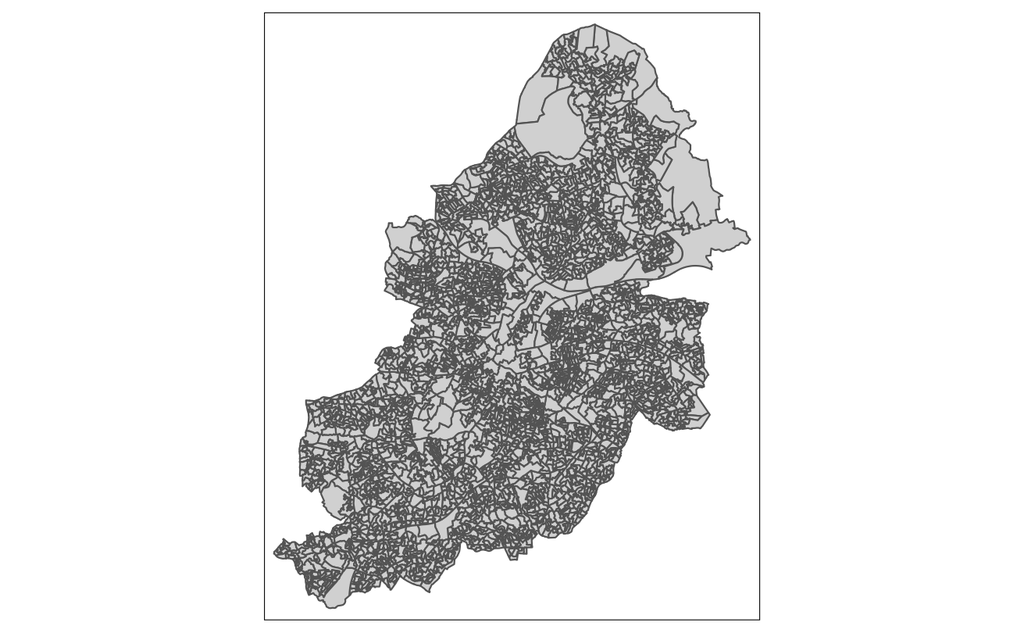

```r
tm_shape(Bham_LSOA) + tm_fill() + tm_borders()
```

```r
qtm(Bham_LSOA)
```

To link the census data to the shapefile we need to join the census data using the unique name of every LSOA as a key or index. But before we do that lets compare the files.

```r
str(Bham_data)
```

[output not shown]

Recall this has 5 columns with the Code column housing the unique LSOA codes and the other four data relating to each LSOA. Where as the shapefile looks like this

```r
glimpse(Bham_LSOA)
```

```
Rows: 3,218
Columns: 3
$ oa11cd   <chr> "E00045077", "E00045078", "E00045079", "E00045080", "E000450…
$ lsoa11cd <chr> "E01008891", "E01008893", "E01008894", "E01008889", "E010088…
$ geometry <MULTIPOLYGON [m]> MULTIPOLYGON (((413029.9 28..., MULTIPOLYGON ((…
```

```r
bham_LSOA_census <- merge(Bham_data, test, by.x="Code", by.y="LSOA11CD")
```

```r
qtm(bham_LSOA_census, fill = "Qualification")
```

[output not shown]

#### Follow-up work

1. Read section *2.4.1** in Lovelace et al. (2024) *Geocomputation with R*. (2nd Ed)

### Citations

- Lovelace, R., Nowosad, J., Meunchow, J. (2024) (2nd Ed.) *Geocomputation with R*. Chapman and Hall. London.
- Tennekes, M. (2018). tmap: Thematic Maps in R. Journal of Statistical Software, 84(6), 1–39.
- Wilkinson, Leland, and Graham Wills. (2005) *The Grammar of Graphics*. Springer Science and Business Media.

Jon Sadler Oct 2024